# ConvergenceAnalysis

Tom Booker

31/01/2021

## Overview of the convergence analysis for the CoAdapTree data

In this RMarkdown, I’ll outline the different parts of the analysis that we’ve thought of for performing a comparative analysis of data obtained in the different conifer species. Aside from the RMarkdown, I have tried to do this all in base R so it is as portable as possible.

For the purposes of this pretend analysis, I’m going to say that I have 5 species and that they form a star shaped phylogeny. I’ll refer to each species as “Species 1” or “S1”

For each reference genome, Pooja and Mengmeng have generated annotations. My understanding is (and I hope Pooja will correct me if I’m way off) is that the term orthogroup is used to refer to genes that are derived from a single lineage (more recently than the whole genome obviously). This means that if there were a set of paralogous genes present in only a single species, this would be an orthogroup. If a gene was present in 3 paralogs in one species, 2 in another, 0 in another and 1 in another that would also be an orthogroup.

Here’s the ortholog summary table that Pooja sent around:

|  | Douglas.Fir | Interior.Spruce | Norway.Spruce | Pine.Pangenome |
| --- | --- | --- | --- | --- |
| Number of genes | 73453.0 | 78627.0 | 66632.0 | 57861.0 |
| Number of genes in orthogroups | 58778.0 | 55877.0 | 52860.0 | 45582.0 |
| Number of unassigned genes | 14675.0 | 22750.0 | 13772.0 | 12279.0 |
| Percentage of genes in orthogroups | 80.0 | 71.1 | 79.3 | 78.8 |
| Percentage of unassigned genes | 20.0 | 28.9 | 20.7 | 21.2 |
| Number of orthogroups containing species | 24405.0 | 27729.0 | 25110.0 | 17006.0 |
| Percentage of orthogroups containing species | 60.2 | 68.4 | 61.9 | 41.9 |
| Number of species-specific orthogroups | 3170.0 | 5066.0 | 2719.0 | 2728.0 |
| Number of genes in species-specific orthogroups | 16979.0 | 14720.0 | 9558.0 | 12879.0 |
| Percentage of genes in species-specific orthogroups | 23.1 | 18.7 | 14.3 | 22.3 |

The number of annotated genes is highly variable across the species. The total number of orthogroups that are present in all species is comparatively low, around 8,000 in total. The overall number of orthogroups is much higher than that though. So we want a method that is amenable to varying levels of missing data - and that is not biased by missing data.

For the rest of this document, I’m going to use simulated data generated under the null to build and test the convergence analysis pipeline.

## Phase 1

[interactive chart not shown]

The first stage of the analysis is to perform a GEA for each species. We have proposed the WZA for the purpose of getting a per-gene score. You could alternatively perform the top-candidate test, or whatever you happened to think was best.

In any case, we’ll end up with a dataframe consisting of per-gene scores for each species. We will rank the scores and convert them to empirical p-values.

```r
## This function makes a list of integers, simulating the number of orthogroup members in a given species
## I'm chopping up this exponential distribution to get a lot of 1s, but some 0s and values greater than 1

makeOrthoGroupMembership <- function(n){
  x <- rexp(n)
  x[x>1] <- floor(x[x>1])
  x[x > 0.2] <- ceiling(x[x>0.2])
  x[x<0.2] <- floor(x[x<0.2])
  return(x)
}

## This next function simulates a WZA on each species by sampling random normal data. These data are then ranked an converted to empirical p-values

makeSpeciesWZA <- function(n){
  orthos <- makeOrthoGroupMembership(n)
  names <- rep(paste("orthogroup",1:n, sep = ""), times = orthos)
  df <- data.frame(orth = names)
  ## Simulate Z scores (I use the mean of 3 and sd of 1.5 for realistic flavour, though this won't make any difference here)
  df$Z <- rnorm(nrow(df), 3, 1.5)
  ## Calculate empirical ps
  df$Z_eP <- 1-(rank(df$Z)/(nrow(df)+1))
  return(df)
}

n_orthogroups = 20000
n_species = 5

# Make a DF for each species
S1_df <- makeSpeciesWZA(n_orthogroups)
S2_df <- makeSpeciesWZA(n_orthogroups)
S3_df <- makeSpeciesWZA(n_orthogroups)
S4_df <- makeSpeciesWZA(n_orthogroups)
S5_df <- makeSpeciesWZA(n_orthogroups)

## We'll have something roughly like this for a single species:

head(S1_df, n = 15)
```

```
##            orth         Z       Z_eP
## 1   orthogroup1 2.0609986 0.73706477
## 2   orthogroup2 3.1716824 0.45686637
## 3   orthogroup4 2.3032098 0.68493484
## 4   orthogroup5 5.7364715 0.03321338
## 5   orthogroup6 3.7524885 0.30752772
## 6   orthogroup7 3.1374395 0.46523050
## 7   orthogroup7 0.4005981 0.95924917
## 8   orthogroup8 3.3162240 0.41762303
## 9   orthogroup8 2.8014990 0.55305388
## 10  orthogroup9 2.8564432 0.53938922
## 11  orthogroup9 2.0380031 0.74236530
## 12 orthogroup10 0.5848834 0.94602217
## 13 orthogroup11 1.8438924 0.78117098
## 14 orthogroup12 1.9872637 0.75345264
## 15 orthogroup13 4.1636117 0.21761330
```

## Phase 2

[interactive chart not shown]

In this phase we are going to get a single p-value for each of the orthogroups present. If there’s a single p-value for a species, no problem! However, if there are multiple members of an orthogroup for a species, we’ll have several p-values. With multiple p-values, there is an increased chance that one of them has an extreme value by chance, so we’ll want to deal with the multiple testing issue. Bonferonni is very passé, so let’s use the Dunn-Šidak. It’s a family-wise error rate correction that is a bit more sensible than the Bonferonni. In the Bonferonni, you just divide alpha by number of tests (or multiply the p-value for each test). In the Dunn-Šidak, you assume independence and raise the (1 - p-value) to m, the number of tests. If you were doing a sequential test you might raise to m/i, where i is the rank index of the p-values. The function `p_value_adjustment` below implements this for the single lowest p-value.

```r
p_value_adjustment <- function(p_vec){
  p_adj = 1 - (1 - min(p_vec))^length(p_vec)
  return(p_adj)
      }


get_orthogroup_p_values <- function( species_DF , speciesLabel){
  gene_Score <- tapply(species_DF$Z_eP, species_DF$orth, p_value_adjustment)
  gene_Score_Names <- names(gene_Score)
  orthoDF <- data.frame(orthogroup = gene_Score_Names, temp = as.numeric(gene_Score)  )
  names(orthoDF) <- c("orthogroup",speciesLabel)
  return(orthoDF)
}



S1_ortho <- get_orthogroup_p_values(S1_df, "S1_p")
S2_ortho <- get_orthogroup_p_values(S2_df, "S2_p")
S3_ortho <- get_orthogroup_p_values(S3_df, "S3_p")
S4_ortho <- get_orthogroup_p_values(S4_df, "S4_p")
S5_ortho <- get_orthogroup_p_values(S5_df, "S5_p")

# merging all the S._ortho DFs into a single frame can be done using the following one-liner
# we do this by re-defining the merge function, hard-coding in some of the arguments so that
# we can retain orthogroups that are missing in one species or another
SpeciesComparison <- Reduce(function(x, y) merge(x, y, by = "orthogroup", all = T),
                            list(S1_ortho, S2_ortho, S3_ortho, S4_ortho, S5_ortho))

head(SpeciesComparison)
```

```
##        orthogroup      S1_p      S2_p        S3_p       S4_p       S5_p
## 1     orthogroup1 0.7370648        NA 0.006363857         NA 0.66284304
## 2    orthogroup10 0.9460222 0.7511895 0.162302648 0.06030417 0.22721090
## 3   orthogroup100 0.7474227 0.7162786 0.802331795         NA 0.31201271
## 4  orthogroup1000 0.8169131 0.6397928 0.761088171 0.12224468 0.73259773
## 5 orthogroup10000 0.7241295 0.7739270 0.840903571 0.99422466 0.07598858
## 6 orthogroup10001 0.2699378 0.4618675 0.411610396 0.31292713 0.44039495
```

Now we have a single dataframe that contains the p-values for each orthogroup in each species. We can now go ahead and perform a convergence analysis on these.

I’m also going to run the above analysis with no p-value adjustment, just to take a little looksie.

```r
p_value_no_adjustment <- function(p_vec){
  min( p_vec )
  }

get_orthogroup_p_values_noAdjust <- function( species_DF , speciesLabel){
  gene_Score <- tapply(species_DF$Z_eP, species_DF$orth, p_value_no_adjustment)
  gene_Score_Names <- names(gene_Score)
  orthoDF <- data.frame(orthogroup = gene_Score_Names, temp = as.numeric(gene_Score)  )
  names(orthoDF) <- c("orthogroup",speciesLabel)
  return(orthoDF)
}

S1_ortho_noAdjust <- get_orthogroup_p_values_noAdjust(S1_df, "S1_p")
S2_ortho_noAdjust <- get_orthogroup_p_values_noAdjust(S2_df, "S2_p")
S3_ortho_noAdjust <- get_orthogroup_p_values_noAdjust(S3_df, "S3_p")
S4_ortho_noAdjust <- get_orthogroup_p_values_noAdjust(S4_df, "S4_p")
S5_ortho_noAdjust <- get_orthogroup_p_values_noAdjust(S5_df, "S5_p")


SpeciesComparison_noAdjust <- Reduce(function(x, y) merge(x, y, by = "orthogroup", all = T),
                            list(S1_ortho_noAdjust, S2_ortho_noAdjust, S3_ortho_noAdjust, S4_ortho_noAdjust, S5_ortho_noAdjust))
```

## Phase 3

[interactive chart not shown]

In this phase we apply the pMax test to the results. The the various tweaks we have made to the pMax, we now have a statistical test that makes use of order statistics to ask whether a paricular ortholog shows a strange pattern of rankings consistent with convergent evolution.

```r
# First define the pMax function for the data
p_jth <- function(plist,j) {
  # get the list of the p-value vector
  k=length(plist)
  # return an NA if the j parameter is bigger than the length of the p vector
  if(j>k) {return(NA)}
  # sort the p-values
  pjth=sort(plist)[j]
  # scale the probabilities
  prob = if(j<k) (pjth /sort(plist)[j+1]) else max(plist)
  # perform the test
  dbinom(x = j, size = j, prob=prob )
}


## Here's a wrapper function to run pMax on the simulated ortholog datasets
run_pMax <- function(species_DF, n_species, max_n){
  # Make a matrix of the p-values from the species dataframe
  species_M <- as.matrix(species_DF[,2:(n_species+1)])

  # create and empty list to put results in
  pMax_results = list()
  # loop over the different convergence configurations
  for (n in 1:max_n){
    # This ugly line applies the p_jth function to each line of the matrix using the current configuration
    pMax_results_temp = apply(species_M, 1, function(x) p_jth( x[!is.na(x)], n) )
    # now just plop the results in the list
    pMax_results[[n]] = pMax_results_temp
  }
  # Convert the results into a nice data frame
  pMax_DF = as.data.frame( do.call(cbind, pMax_results) )
  # Give the columns infomative names
  names(pMax_DF) = paste("pMax_",1:max_n, sep = '')
  # done
  return(cbind( species_DF, pMax_DF ))
}



# Run the p_jth procedure on the p-value adjusted data
SpeciesComparison_pMax <- run_pMax(SpeciesComparison, n_species, n_species)

# Run the p_jth procedure on the unadjusted data
SpeciesComparison_pMax_noAdjust <- run_pMax(SpeciesComparison_noAdjust, n_species, n_species)
```

Great, now we’ve run the pMax on each of the orthologs present in all the species.

Now let’s take a look at the results. If everything went according to plan then we should have a nice uniform distribution of pMax results for each level of comparison…

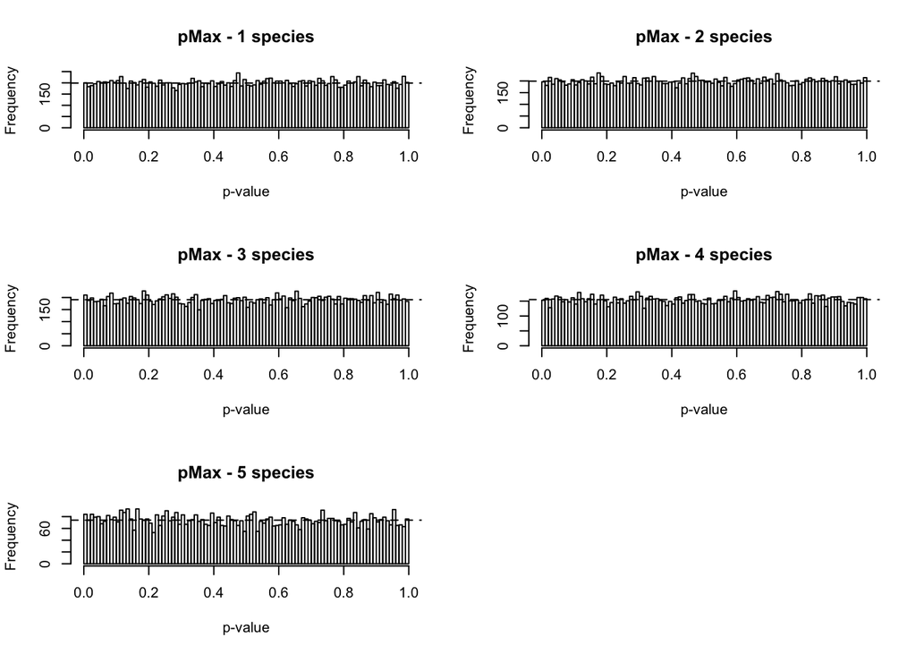

```r
par(mfrow=c(3,2))
## These are self explanatory histograms of the results
hist(SpeciesComparison_pMax$pMax_1, main = "pMax - 1 species", xlab = "p-value", breaks = 100)
abline( h = length(na.omit(SpeciesComparison_pMax$pMax_2))/100, lty = 2)

hist(SpeciesComparison_pMax$pMax_2, main = "pMax - 2 species", xlab = "p-value", breaks = 100)
abline( h = length(na.omit(SpeciesComparison_pMax$pMax_2))/100, lty = 2)

hist(SpeciesComparison_pMax$pMax_3, main = "pMax - 3 species", xlab = "p-value", breaks = 100)
abline( h = length(na.omit(SpeciesComparison_pMax$pMax_3))/100, lty = 2)

hist(SpeciesComparison_pMax$pMax_4, main = "pMax - 4 species", xlab = "p-value", breaks = 100)
abline( h = length(na.omit(SpeciesComparison_pMax$pMax_4))/100, lty = 2)

hist(SpeciesComparison_pMax$pMax_5, main = "pMax - 5 species", xlab = "p-value", breaks = 100)
abline( h = length(na.omit(SpeciesComparison_pMax$pMax_5))/100, lty = 2)
```

The horizontal dashed line indicates the expected number of orthogroups falling into each of the frequency bins

As you might expect, not correcting for multiple comparisons when getting the per-orthogroup scores results in a lot of false positives…

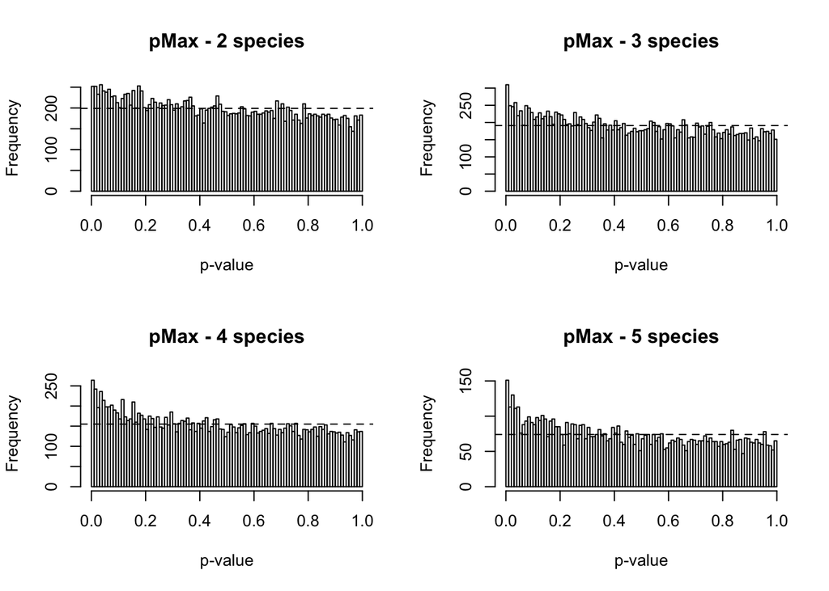

```r
par(mfrow=c(2,2))
hist(SpeciesComparison_pMax_noAdjust$pMax_2, main = "pMax - 2 species", xlab = "p-value", breaks = 100)
abline( h = length(na.omit(SpeciesComparison_pMax_noAdjust$pMax_2))/100, lty = 2)

hist(SpeciesComparison_pMax_noAdjust$pMax_3, main = "pMax - 3 species", xlab = "p-value", breaks = 100)
abline( h = length(na.omit(SpeciesComparison_pMax_noAdjust$pMax_3))/100, lty = 2)

hist(SpeciesComparison_pMax_noAdjust$pMax_4, main = "pMax - 4 species", xlab = "p-value", breaks = 100)
abline( h = length(na.omit(SpeciesComparison_pMax_noAdjust$pMax_4))/100, lty = 2)

hist(SpeciesComparison_pMax_noAdjust$pMax_5, main = "pMax - 5 species", xlab = "p-value", breaks = 100)
abline( h = length(na.omit(SpeciesComparison_pMax_noAdjust$pMax_5))/100, lty = 2)
```

## Phase 4

[interactive chart not shown]

So now we have a pMax score for each of the possible comparisons. What are we going to do with that information?

What we propose is to take the minimum p-value from the list and perform the same p-value adjustment that we described above. This assumes that there is no correlation among the p-values under the null. Let’s look at that.

Here’s the correlation matrix among the various tests

```r
## Start by grabbing the relevant part of the dataframe
SpeciesComparison_pMax_only <- SpeciesComparison_pMax[,7:10]
# Due to missing data, we need to use the "pair-wise complete observations option so we don't just propagate NAs
cor(SpeciesComparison_pMax_only, use = "pairwise.complete.obs")
```

```
##             pMax_1        pMax_2      pMax_3        pMax_4
## pMax_1  1.00000000 -0.0018264605  0.01188068  0.0105352709
## pMax_2 -0.00182646  1.0000000000 -0.01212509 -0.0009781187
## pMax_3  0.01188068 -0.0121250896  1.00000000  0.0163356402
## pMax_4  0.01053527 -0.0009781187  0.01633564  1.0000000000
```

Phew, there are no strong correlations among the different p_jth levels. That’s what we were expecting, but it’s good to double check.

So far we’ve worked wih null data generated with the orthogroup info. In the next part we are going to examine the statistical power of the p_jth procedure when there are true positives. For this we will use simulated data, but aren’t going to use the orthogroup approach, just for convenience.

Let’s repeat the above and generate with a set of null observations, but that have no missing data. Here are some functions to simulate correlated data and apply the p_jth test.

```r
## Here's a function for simulating correlated data

simulateCorrelation <- function(r, n = 100){
# r is the population correlation coefficient
# x1 is the sample data
    x1 = rnorm(n)
# x2 is the data that will be transformed so as to be correlated with x1
    x2 = rnorm(n)

    Y = r*x1+sqrt(1-r*r)*x2
    return( cor.test(Y, x1)$p.value )
}

## Now make the function run in a vectorised fashion
simulateCorrelationVectorized <- Vectorize(simulateCorrelation)

# Wrap the function up so that it takes a vector of correlations for each "species"
# and returns the data in a nice way
simulateMultipleGEAs <- function(corVector, times){
  # t is for transpose
    t(replicate(times,  simulateCorrelationVectorized(corVector, n = 40) )  )
}

simulateMultipleGEAs_beta <- function(corVector, a, b, times){
  # t is for transpose
  correlations <- c(rbeta(sum(corVector!=0), a, b), rep(0, length(corVector) - sum(corVector!=0)))
    t(replicate(times,  simulateCorrelationVectorized(correlations, n = 40) )  )
}

## Note that the 'n = 20' in the above specifies that a sample of 20 is being taken.
#This is a relatively small number to make things nice and noisy

## Here's a wrapper function that runs the pMax on the 2, 3, 4 and 5 case. To be used later...
p_jth_wrapper <- function( correlationSet ){
  p1th <- apply(correlationSet, 1, function(x) p_jth(x,1))
  p2th <- apply(correlationSet, 1, function(x) p_jth(x,2))
  p3th <- apply(correlationSet, 1, function(x) p_jth(x,3))
  p4th <- apply(correlationSet, 1, function(x) p_jth(x,4))
  p5th <- apply(correlationSet, 1, function(x) p_jth(x,5))

  return( data.frame(p1 = p1th, p2 = p2th, p3 = p3th, p4 = p4th, p5 = p5th) )
}
```

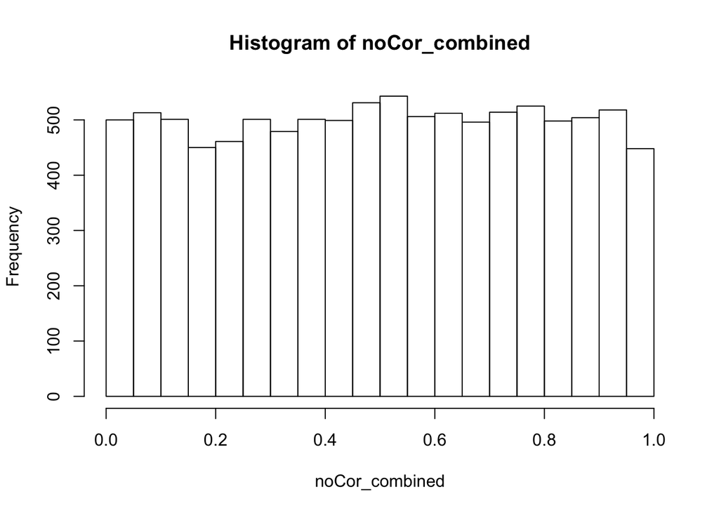

```r
## Let's start with a case with no correlation (10000 replicates)
## The vector of zeroes is the population correlation for each "species"
noCorrelationSet <- simulateMultipleGEAs( c(0.0, 0.0, 0.0, 0.0, 0.0), 10000)

## run the procedure using the wrapper function
noCor_result  <- p_jth_wrapper( noCorrelationSet )


## Let's now look at the top hits across the p_j tests
noCor_combined <- apply(as.matrix(noCor_result), 1, p_value_adjustment)

## A nice uniform distribution - that's what we want to see!
hist(noCor_combined)
```

Additionally, here’s the correlation matrix for this null data:

```
##              p1           p2            p3           p4            p5
## p1  1.000000000 -0.005142273 -0.0122878551 -0.006023536 -0.0122246919
## p2 -0.005142273  1.000000000  0.0092202700  0.005494846  0.0033744416
## p3 -0.012287855  0.009220270  1.0000000000  0.002684665 -0.0009570266
## p4 -0.006023536  0.005494846  0.0026846648  1.000000000 -0.0114208052
## p5 -0.012224692  0.003374442 -0.0009570266 -0.011420805  1.0000000000
```

On this simulated data, the test is well-behaved and works as it should.